# Anderson

Topics that will be discussed in this summary report for Anderson County are

- Demographic Characteristics
  - Population growth from 1970 to 2020;
  - population density
  - sex, race, and age
  - educational level of the adult population
  - housing characteristics in terms of age of the housing stock and type of tenure
- Economic Characteristics
  - family income, household income, per capita income,
  - poverty status of families;
  - employment classification according to industry;
  - labor force by place of work and commuting patterns;

For more details on the data used, please see the Data Description tab.

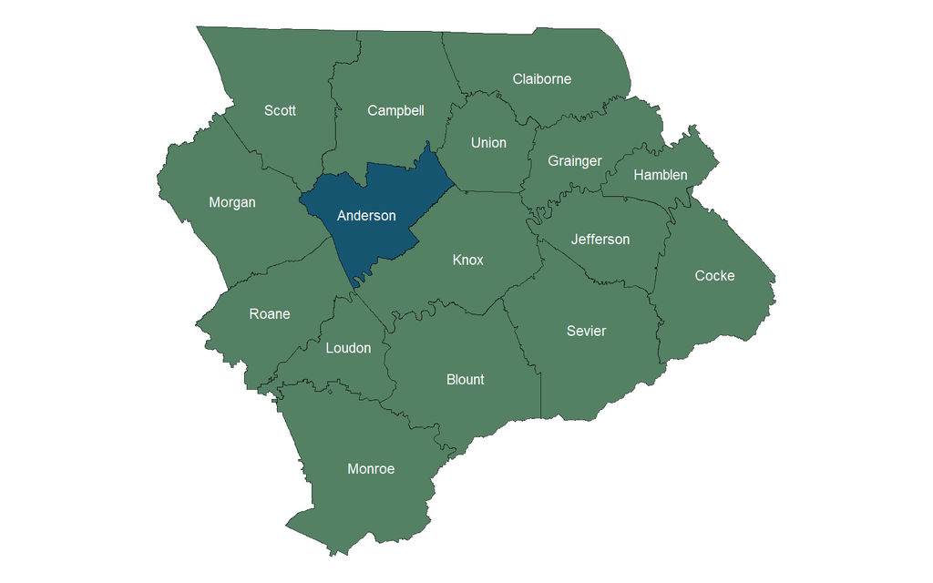

**Population and Growth**

| Place | 1970 | 1980 | 1990 | 2000 | 2010 | 2020 | Change 1970-1980 | Change 1980-1990 | Change 1990-2000 | Change 2000-2010 | Change 2010-2020 |
| --- | --- | --- | --- | --- | --- | --- | --- | --- | --- | --- | --- |
| Anderson County | 60300 | 67346 | 68250 | 71330 | 75129 | 77123 | 7046 | 904 | 3080 | 3799 | 1994 |
| Clinton | 4794 | 5245 | 8972 | 9409 | 9841 | 10056 | 451 | 3727 | 437 | 432 | 215 |
| Rocky Top | 1923 | 2335 | 2166 | 1888 | 1781 | 1628 | 412 | -169 | -278 | -107 | -153 |
| Norris | 1359 | 1374 | 1303 | 1446 | 1491 | 1599 | 15 | -71 | 143 | 45 | 108 |
| Oak Ridge | 28319 | 27662 | 27310 | 27387 | 29330 | 31402 | -657 | -352 | 77 | 1943 | 2072 |
| Oliver Springs | 3405 | 3659 | 3433 | 3303 | 3231 | 3297 | 254 | -226 | -130 | -72 | 66 |

[interactive chart not shown]

IPUMS NHGIS, University of Minnesota, www.nhgis.org

**Population Density**

| Place | Area | Population Density |
| --- | --- | --- |
| Anderson County | 344.7348190361589 | 223.7168853892611 |
| Clinton | 12.24068647159913 | 821.5225529492939 |
| Norris | 8.33133271029709 | 191.926076607614 |
| Oak Ridge | 89.94021625585238 | 349.1430341980825 |
| Oliver Springs | 5.773579302566441 | 571.049573794619 |
| Rocky Top(a) | 1.618808543105151 | 1005.677914744148 |

[interactive chart not shown]

source: U. S. Census Bureau *Decennial Census: Redistricting Data (PL 94-171)*, 2020, accessed June 2, 2026, http://api.census.gov/data/2020/dec/pl.

**Population Descriptions**

| Place | Year | Race Category | Number of People | Percentage of People |
| --- | --- | --- | --- | --- |
| Anderson County | 2020 | Black | 2888 | 0.02308460892850006 |
| Anderson County | 2020 | Other | 7372 | 0.05892650173853962 |
| Anderson County | 2020 | White | 66863 | 0.5344550577514887 |
| Clinton | 2020 | Black | 245 | 0.001958354981815275 |
| Clinton | 2020 | Other | 768 | 0.006138843371567883 |
| Clinton | 2020 | White | 9043 | 0.0722832820430838 |
| Norris | 2020 | Black | 6 | 4.795971384037409e-05 |
| Norris | 2020 | Other | 87 | 0.0006954158506854242 |
| Norris | 2020 | White | 1506 | 0.0120378881739339 |
| Oak Ridge | 2020 | Black | 2353 | 0.0188082011110667 |

[output cut: 8 more lines]

| Place | Sex | Age Range | Year | Number of People | Percentage of People |
| --- | --- | --- | --- | --- | --- |
| Anderson County | Female | 10 to 14 years | 2020 | 2464 | 0.01999772753096239 |
| Anderson County | Female | 15 to 19 years | 2020 | 2091 | 0.01697047413443278 |
| Anderson County | Female | 20 to 24 years | 2020 | 2018 | 0.01637800899248462 |
| Anderson County | Female | 25 to 29 years | 2020 | 2396 | 0.01944584219325726 |
| Anderson County | Female | 30 to 34 years | 2020 | 2300 | 0.01866670995179119 |
| Anderson County | Female | 35 to 39 years | 2020 | 2160 | 0.01753047543298651 |
| Anderson County | Female | 40 to 44 years | 2020 | 2143 | 0.01739250409856023 |
| Anderson County | Female | 45 to 49 years | 2020 | 2646 | 0.02147483240540848 |
| Anderson County | Female | 5 to 9 years | 2020 | 1997 | 0.01620757381466392 |
| Anderson County | Female | 50 to 54 years | 2020 | 2707 | 0.02196990601717337 |

[output cut: 206 more lines]

[interactive chart not shown]

source: U. S. Census Bureau *Decennial Census: Redistricting Data (PL 94-171)*, 2020, accessed June 2, 2026, http://api.census.gov/data/2020/dec/pl.

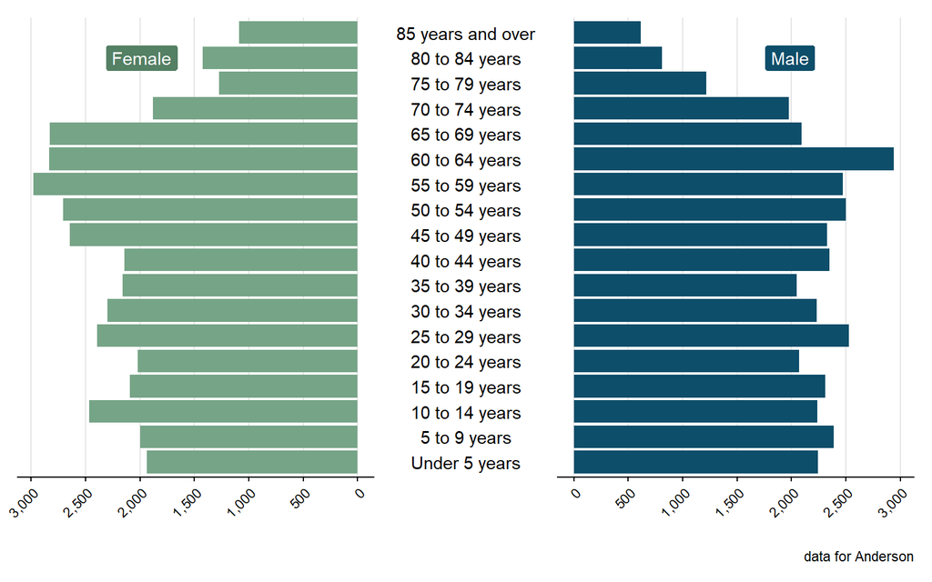

source: U. S. Census Bureau *American Community Survey 5-Year Estimates: Comparison Profiles 5-Year*, 2020, accessed June 2, 2026, http://api.census.gov/data/2020/acs/acs5.

**Education**

| Place | Level of Education | Year | Number of People | Percentage of People |
| --- | --- | --- | --- | --- |
| Anderson County | 9th to 12th Grade, No Diploma | 2010 | 4078 | 0.04963969227772909 |
| Anderson County | Associate's degree | 2010 | 3342 | 0.04068068945369559 |
| Anderson County | Bachelor's degree | 2010 | 6713 | 0.0817143830947512 |
| Anderson County | Graduate or Professional Degree | 2010 | 4782 | 0.05820917323984809 |
| Anderson County | Less Than 9th Grade | 2010 | 3322 | 0.04043723828999903 |
| Anderson County | Some College, No Degree | 2010 | 10116 | 0.1231375985977213 |
| Anderson County | Total | 2010 | 51932 | 0.6321452916544941 |
| Anderson County | 9th to 12th Grade, No Diploma | 2020 | 2849 | 0.03236801145207285 |
| Anderson County | Associate's degree | 2020 | 4521 | 0.05136391006487236 |
| Anderson County | Bachelor's degree | 2020 | 6848 | 0.07780138379213579 |

[output cut: 67 more lines]

[interactive chart not shown]

source: U. S. Census Bureau *American Community Survey 5-Year Estimates: Comparison Profiles 5-Year*, 2020, accessed June 2, 2026, http://api.census.gov/data/2020/acs/acs5.

**Housing Units by Year of Construction**

| Place | Year | 1939 or earlier | 1940-1959 | 1960-1979 | 1980 to 1989 | 1990 to 1999 | 2000 to 2004 | 2005 or later | 2000 to 2009 | 2010 or later | Total |
| --- | --- | --- | --- | --- | --- | --- | --- | --- | --- | --- | --- |
| Anderson County | 2010 | 2026 | 10915 | 8866 | 4812 | 4656 | 2067 | 1167 |  |  | 34509 |
| Anderson County | 2020 | 1545 | 8979 | 9358 | 5027 | 5076 |  |  | 3672 | 1400 | 35057 |
| Clinton | 2010 | 374 | 1167 | 1328 | 1026 | 436 | 154 | 62 |  |  | 4547 |
| Norris | 2010 | 243 | 193 | 150 | 51 | 106 | 15 | 0 |  |  | 758 |
| Oak Ridge | 2010 | 523 | 6803 | 3763 | 1234 | 990 | 470 | 496 |  |  | 14279 |
| Oliver Springs | 2010 | 61 | 417 | 563 | 297 | 42 | 27 | 21 |  |  | 1428 |
| Clinton | 2020 | 143 | 880 | 1583 | 1040 | 858 |  |  | 442 | 78 | 5024 |
| Norris | 2020 | 229 | 172 | 141 | 24 | 139 |  |  | 133 | 4 | 842 |
| Oak Ridge | 2020 | 113 | 6178 | 3636 | 1432 | 987 |  |  | 1053 | 753 | 14152 |
| Oliver Springs | 2020 | 170 | 283 | 708 | 361 | 113 |  |  | 34 | 0 | 1669 |

[output cut: 1 more lines]

[interactive chart not shown]

source: U. S. Census Bureau *Decennial Census: Redistricting Data (PL 94-171)*, 2020, accessed June 2, 2026, http://api.census.gov/data/2020/dec/pl.

**Housing Units by Type of Tenure**

| Place | Year | Own | Rent | Total |
| --- | --- | --- | --- | --- |
| Anderson County | 2010 | 22202 | 8737 | 30939 |
| Anderson County | 2020 | 20886 | 10000 | 30886 |
| Clinton | 2010 | 2553 | 1897 | 4450 |
| Norris | 2010 | 532 | 162 | 694 |
| Oak Ridge | 2010 | 8420 | 4266 | 12686 |
| Oliver Springs | 2010 | 999 | 306 | 1305 |
| Clinton | 2020 | 2375 | 2055 | 4430 |
| Norris | 2020 | 595 | 167 | 762 |
| Oak Ridge | 2020 | 7325 | 4748 | 12073 |
| Oliver Springs | 2020 | 1126 | 480 | 1606 |

[output cut: 1 more lines]

[interactive chart not shown]

source: U. S. Census Bureau *Decennial Census: Redistricting Data (PL 94-171)*, 2020, accessed June 2, 2026, http://api.census.gov/data/2020/dec/pl.

**Income Comparison**

| Place | Year | Median Family Income | Median Household Income | Per Capita Income |
| --- | --- | --- | --- | --- |
| Anderson County | 2020 | 63457 | 52338 | 28633 |
| Clinton | 2020 | 63542 | 50158 | 28999 |
| Norris | 2020 | 120380 | 60000 | 44370 |
| Oak Ridge | 2020 | 67282 | 55869 | 32160 |
| Oliver Springs | 2020 | 63036 | 49375 | 21416 |
| Rocky Top | 2020 | 39028 | 26827 | 15045 |

[interactive chart not shown]

source: U. S. Census Bureau *Decennial Census: Redistricting Data (PL 94-171)*, 2020, accessed June 2, 2026, http://api.census.gov/data/2020/dec/pl.

**Povery Status**

| Place | Year | Above Poverty | Below Poverty |
| --- | --- | --- | --- |
| Anderson County | 2020 | 18530 | 2511 |
| Clinton | 2020 | 2754 | 395 |
| Norris | 2020 | 477 | 0 |
| Oak Ridge | 2020 | 6752 | 938 |
| Oliver Springs | 2020 | 788 | 108 |
| Rocky Top | 2020 | 305 | 160 |

[interactive chart not shown]

source: U. S. Census Bureau *American Community Survey 5-Year Estimates: Comparison Profiles 5-Year*, 2020, accessed June 2, 2026, http://api.census.gov/data/2020/acs/acs5.

**Poverty Status by Family Type**

| Place | Poverty Status | Family Type | Number of Families | Year | Percentage of Families |
| --- | --- | --- | --- | --- | --- |
| Anderson County | Above Poverty | All Families | 18530 | 2020 | 0.5495580995314076 |
| Anderson County | Above Poverty | Female Householder | 2767 | 2020 | 0.0820629930600866 |
| Anderson County | Above Poverty | Female Householder with related children | 1617 | 2020 | 0.04795658105462958 |
| Anderson County | Below Poverty | All Families | 2511 | 2020 | 0.07447060917017617 |
| Anderson County | Below Poverty | Female Householder | 1181 | 2020 | 0.03502580224212587 |
| Anderson County | Below Poverty | Female Householder with related children | 972 | 2020 | 0.02882733258200368 |
| Clinton | Above Poverty | All Families | 2754 | 2020 | 0.08167744231567708 |
| Clinton | Above Poverty | Female Householder | 409 | 2020 | 0.01213001957411472 |
| Clinton | Above Poverty | Female Householder with related children | 134 | 2020 | 0.003974138442374993 |
| Clinton | Below Poverty | All Families | 395 | 2020 | 0.01171481108013524 |

[output cut: 26 more lines]

[interactive chart not shown]

source: U. S. Census Bureau *American Community Survey 5-Year Estimates: Comparison Profiles 5-Year*, 2020, accessed June 2, 2026, http://api.census.gov/data/2020/acs/acs5.

**Employment by Industry**

| Place | Industry | Year | Number of Jobs | Percentage of Jobs |
| --- | --- | --- | --- | --- |
| Anderson County | Arts, Entertainment, And Recreation, And Accommodation And Food Services | 2010 | 2178 | 0.06900266125966291 |
| Anderson County | Arts, Entertainment, And Recreation, And Accommodation And Food Services | 2020 | 2799 | 0.641384051329056 |
| Anderson County | Educational Services, And Health Care And Social Assistance | 2010 | 6736 | 0.2134076796350272 |
| Anderson County | Educational Services, And Health Care And Social Assistance | 2020 | 7271 | 1.666131989000917 |
| Anderson County | Manufacturing | 2010 | 4307 | 0.1364529210492967 |
| Anderson County | Manufacturing | 2020 | 3394 | 0.7777268560953254 |
| Anderson County | Other Industries | 2010 | 14955 | 0.4737992649854265 |
| Anderson County | Other Industries | 2020 | 10348 | 2.37121906507791 |
| Anderson County | Professional, Scientific, And Management, And Administrative, And Waste Management Services | 2020 | 5145 | 0.1586983343615052 |
| Anderson County | Retail Trade | 2010 | 3388 | 0.1073374730705867 |

[output cut: 51 more lines]

[interactive chart not shown]

source: U. S. Census Bureau *American Community Survey 5-Year Estimates: Comparison Profiles 5-Year*, 2020, accessed June 2, 2026, http://api.census.gov/data/2020/acs/acs5.

**Employment by Industry (Historical)**

| Place | Year | Industry | Number of Jobs | Percentage of Jobs |
| --- | --- | --- | --- | --- |
| Anderson County | 2010 | Agriculture, Forestry, Fishing And Hunting, And Mining | 202 | 0.004038223181800008 |
| Anderson County | 2010 | Construction | 2704 | 0.05405621526528327 |
| Anderson County | 2010 | Manufacturing | 4307 | 0.08610211506936948 |
| Anderson County | 2010 | Other | 1380 | 0.02758786134100995 |
| Anderson County | 2010 | Professional Services | 14324 | 0.2863540042381352 |
| Anderson County | 2010 | Public Administration | 1606 | 0.03210587341569709 |
| Anderson County | 2010 | Trade, Finance, Insurance &amp; Real Estate | 7041 | 0.1407580664507617 |
| Anderson County | 2020 | Agriculture, Forestry, Fishing And Hunting, And Mining | 118 | 0.002254791431792559 |
| Anderson County | 2020 | Construction | 2591 | 0.04950986948961458 |
| Anderson County | 2020 | Manufacturing | 3394 | 0.06485391626698259 |

[output cut: 67 more lines]

**Labor Force by Place of Work**

| Place | Year | Work Out Of State | Work Out of County of Residence | Work in County of Residence |
| --- | --- | --- | --- | --- |
| Anderson County | 2020 | 367 | 12873 | 18544 |
| Clinton | 2020 | 70 | 1737 | 2457 |
| Norris | 2020 | 0 | 309 | 446 |
| Oak Ridge | 2020 | 173 | 5359 | 6939 |
| Oliver Springs | 2020 | 0 | 767 | 462 |
| Rocky Top | 2020 | 0 | 372 | 370 |

[interactive chart not shown]

source: U. S. Census Bureau *American Community Survey 5-Year Estimates: Comparison Profiles 5-Year*, 2020, accessed June 2, 2026, http://api.census.gov/data/2020/acs/acs5.

**Commuting Patterns**

| Home County | Year | Number of Jobs | Percentage of Jobs |
| --- | --- | --- | --- |
| Knox | 2020 | 17129 | 0.1849504394583972 |
| Knox | 2010 | 13666 | 0.1475586844321593 |
| Anderson | 2010 | 13248 | 0.1430453279201848 |
| Anderson | 2020 | 12645 | 0.1365344332390351 |
| Roane | 2010 | 4641 | 0.05011121428725679 |
| Roane | 2020 | 4471 | 0.04827563867233896 |
| Blount | 2020 | 1953 | 0.02108752456432073 |
| Blount | 2010 | 1466 | 0.015829140302762 |
| Davidson | 2010 | 235 | 0.002537413350033472 |
| Davidson | 2020 | 206 | 0.002224285745135725 |

[output cut: 3 more lines]

| Work County | Year | Number of Jobs | Percentage of Jobs |
| --- | --- | --- | --- |
| Anderson | 2010 | 13248 | 0.1430453279201848 |
| Anderson | 2020 | 12645 | 0.1365344332390351 |
| Knox | 2020 | 11122 | 0.1200898352300948 |
| Knox | 2010 | 9242 | 0.09979052842982702 |
| Blount | 2020 | 984 | 0.01062474355928909 |
| Roane | 2020 | 807 | 0.008713585419051116 |
| Blount | 2010 | 704 | 0.007601442546483253 |
| Roane | 2010 | 580 | 0.006262552097954953 |
| Campbell | 2020 | 438 | 0.004729306584317706 |
| Campbell | 2010 | 363 | 0.003919493813030427 |

[output cut: 3 more lines]

[interactive chart not shown]

source: U. S. Census Bureau *Tn_od_main_JT00_2020*, LEHD Origin-Destination Employment Statistics, 8.3, 2020, accessed June 2, 2026, https://lehd.ces.census.gov/data/lodes/.

## References

Bureau, U. S. Census. *American Community Survey 5-Year Estimates: Comparison Profiles 5-Year*. 2020. Accessed June 2, 2026. http://api.census.gov/data/2020/acs/acs5.

Bureau, U. S. Census. *Decennial Census: Redistricting Data (PL 94-171)*. 2020. Accessed June 2, 2026. http://api.census.gov/data/2020/dec/pl.

Bureau, U. S. Census. *Tn_od_main_JT00_2020*. LEHD Origin-Destination Employment Statistics, 8.3. 2020. Accessed June 2, 2026. https://lehd.ces.census.gov/data/lodes/.